# PCA Image Compression

### Image Compression Function

```r
compress_image <- function(img_matrix, k) {
  # 1. Calculate the cross product V = X'X
  V <- t(img_matrix) %*% img_matrix

  # 2. Get the eigendecomposition of V (U becomes our matrix of eigenvectors)
  decomp <- eigen(V)
  U <- decomp$vectors

  # 3. Calculate the principal component scores (Z = XU)
  Z <- img_matrix %*% U

  # 4. Create the rank k approximation. We subset the first k columns of Z and U
  Z_k <- Z[, 1:k, drop = FALSE]
  U_k <- U[, 1:k, drop = FALSE]

  # X^(k) = Z_k * U_k'
  X_k <- Z_k %*% t(U_k)

  # 5. Calculate the Frobenius norm error
  approx_error <- norm(img_matrix - X_k, type = "F")

  # 6. Return both pieces of data as a list
  return(list(
    approximation = X_k,
    error = approx_error
  ))
}
```

# Image 1

## Original Image and First 10 Approximations

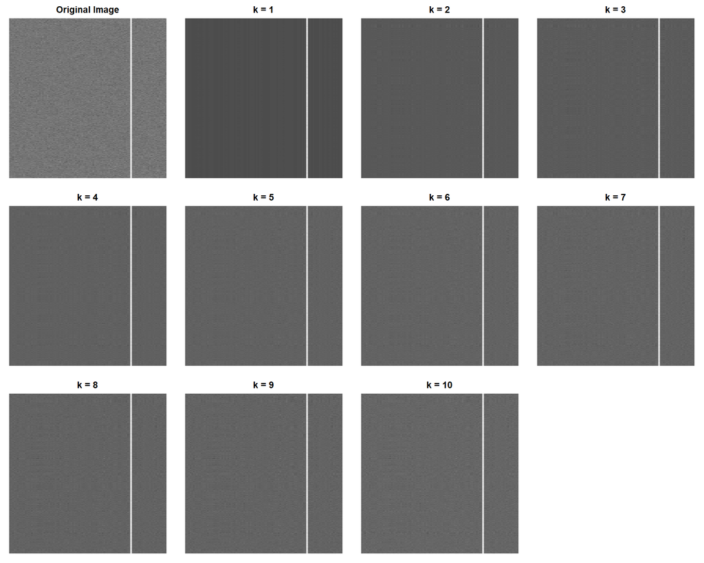

## Approximation Error

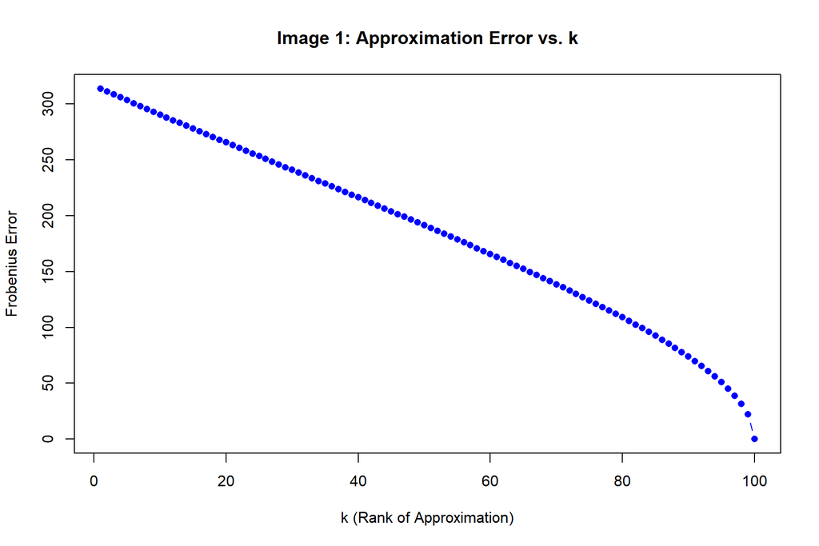

## First Eigenvector and First PC Score

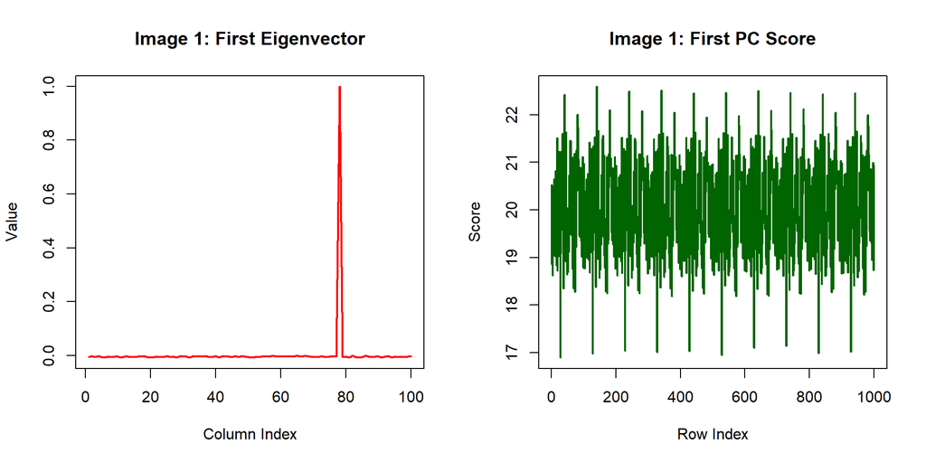

### Interpretation

**Eigenvector & PC Score:**  
The first eigenvector is close to zero for most column positions but has a very large spike near column 80. This indicates that the dominant principal component is mostly associated with the strong vertical feature near that location in the original image. The first PC score varies around a fairly constant level across the rows, with smaller fluctuations caused by the noise in the image. Together, the first eigenvector and first PC score capture the main vertical feature, while the random texture requires many additional principal components.

**Sufficiently Good k:**  
I would choose approximately k = 90 for Image 1. The image contains a large amount of fine, noise-like texture, so the low-rank approximations capture the main vertical line but do not reproduce most of the texture. The approximation error also decreases gradually across almost the entire range of possible values of k, rather than having a strong early elbow. Therefore, a relatively high rank is needed before the approximation becomes close to the original.

### ——————————————————————————–

# Image 2

## Original Image and First 10 Approximations

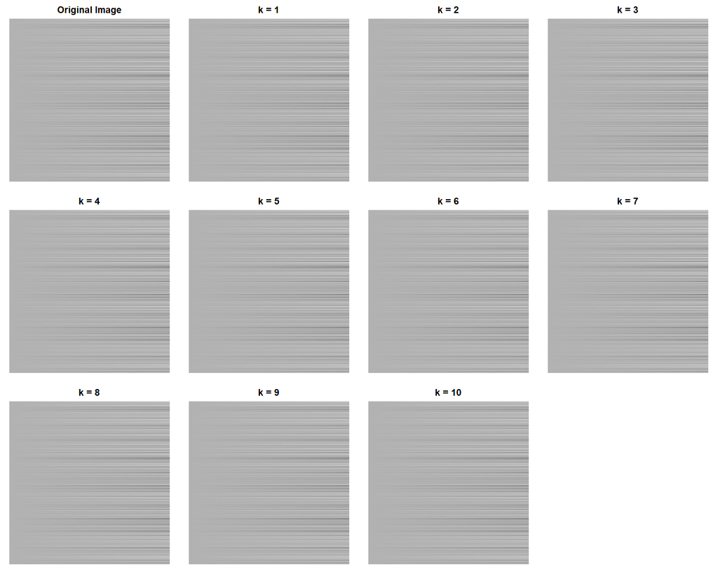

## Approximation Error

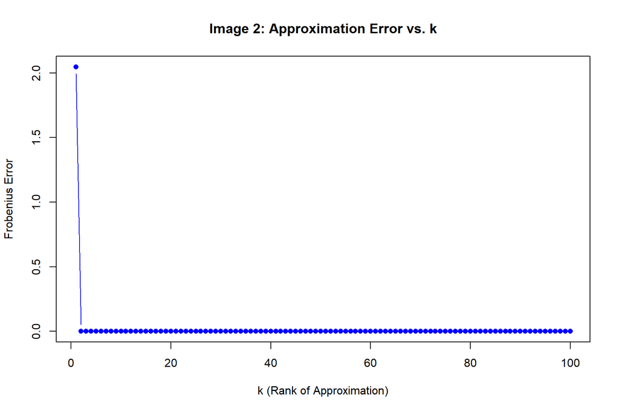

## First Eigenvector and First PC Score

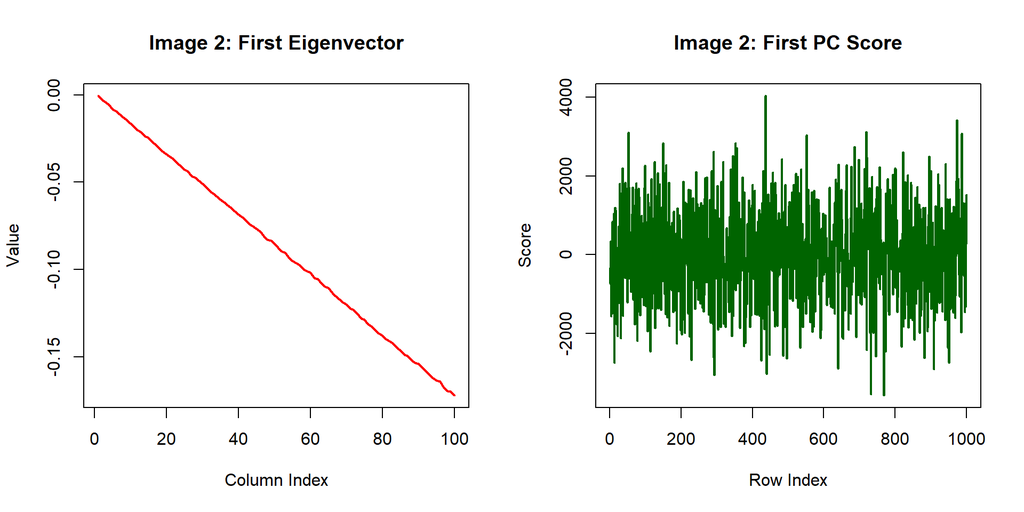

### Interpretation

**Eigenvector & PC Score:**  
The first eigenvector changes smoothly across the columns, approximately following a steady trend from one side of the image to the other. In contrast, the first PC score changes rapidly across the rows. This is consistent with the strong horizontal bands visible in the image, because most of the variation occurs from one row to another. The first principal component therefore captures most of the overall horizontal stripe pattern.

**Sufficiently Good k:**  
I would choose k = 2 for Image 2. The approximation error falls from about 2 at k = 1 to essentially zero at k = 2, and the k = 2 approximation is visually indistinguishable from the original image. Increasing k beyond 2 therefore provides essentially no improvement.

### ——————————————————————————–

# Image 3

## Original Image and First 10 Approximations

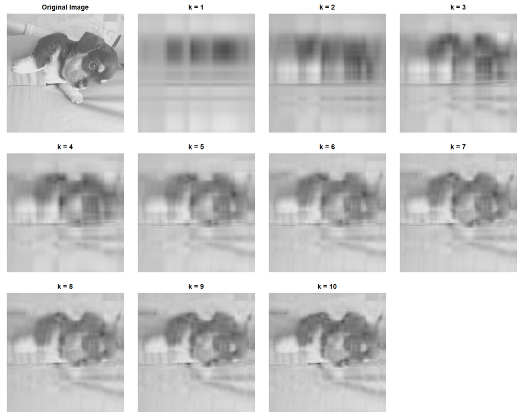

## Approximation Error

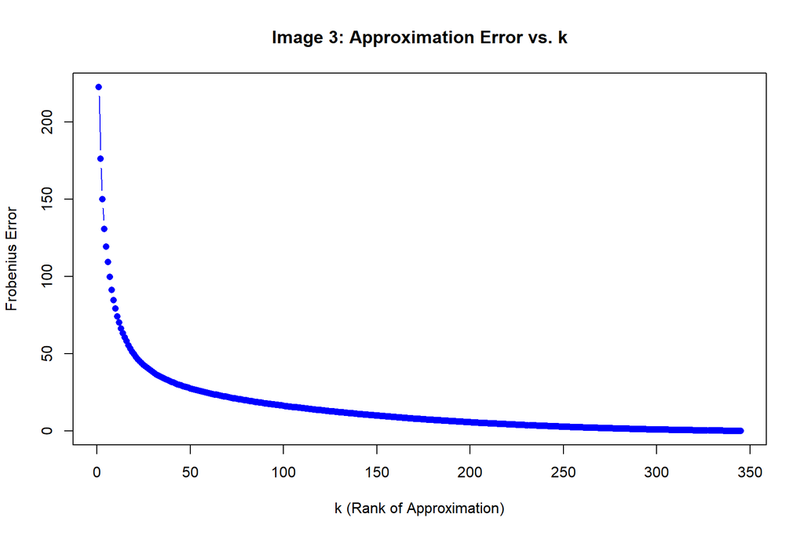

## First Eigenvector and First PC Score

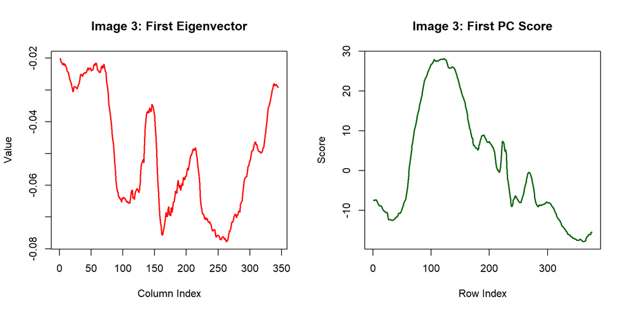

### ——————————————————————————–

# Image 4

## Original Image and First 10 Approximations

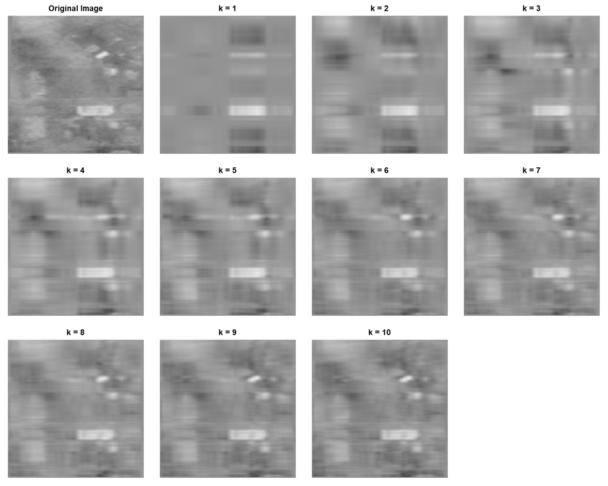

## Approximation Error

[figure not shown]

## First Eigenvector and First PC Score

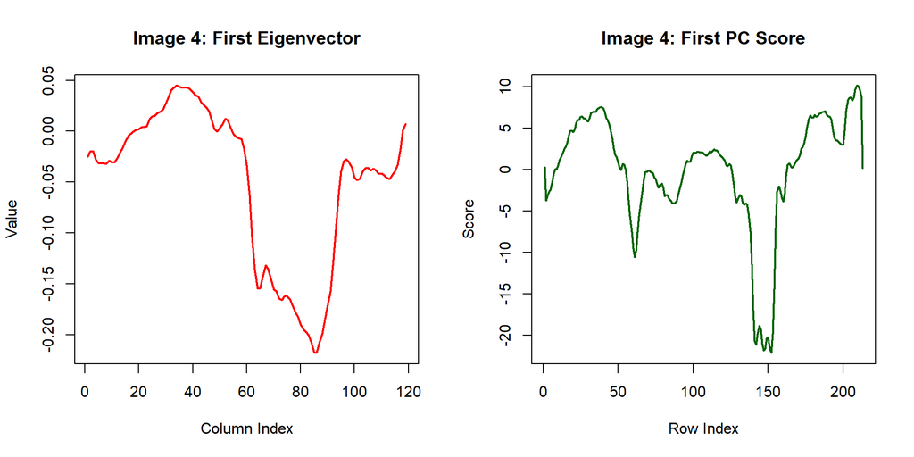

### Interpretation

**Eigenvector & PC Score:**  
The first eigenvector has a large change in magnitude around the middle portion of the columns, showing that this region contributes strongly to the dominant pattern in the image. The first PC score contains several broad changes across the rows, including a particularly large change around the middle-to-lower part of the image. These patterns show that the first principal component is capturing the major light and dark regions of the scene. Additional principal components are needed to reconstruct the smaller objects and texture.

**Sufficiently Good k:**  
I would choose k = 10 for Image 4. The first few approximations are very blurred, but the major objects and contrast patterns become increasingly clear as k increases. At k = 10, the approximation contains most of the large-scale visual structure of the original image even though some fine details are still lost. The error curve decreases sharply at small values of k and then begins to flatten, so increasing the rank beyond this point gives progressively smaller improvements.